# Analysis Report

Shaojing Xia

2020/11/8

# Descriptive Statistics

```r
Salaries <- read.csv("C:/Users/Administrator/Desktop/Modeling Exercise/Salaries.csv")
summary(Salaries)
```

```
##      rank            discipline        yrs.since.phd    yrs.service
##  Length:397         Length:397         Min.   : 1.00   Min.   : 0.00
##  Class :character   Class :character   1st Qu.:12.00   1st Qu.: 7.00
##  Mode  :character   Mode  :character   Median :21.00   Median :16.00
##                                        Mean   :22.31   Mean   :17.61
##                                        3rd Qu.:32.00   3rd Qu.:27.00
##                                        Max.   :56.00   Max.   :60.00
##      sex                salary
##  Length:397         Min.   : 57800
##  Class :character   1st Qu.: 91000
##  Mode  :character   Median :107300
##                     Mean   :113706
##                     3rd Qu.:134185
##                     Max.   :231545
```

```r
table(Salaries$rank)
```

```
##
## AssocProf  AsstProf      Prof
##        64        67       266
```

```r
table(Salaries$discipline)
```

```
##
##   A   B
## 181 216
```

```r
table(Salaries$sex)
```

```
##
## Female   Male
##     39    358
```

```r
Salaries[!complete.cases(Salaries),]#check missing values
```

```
## [1] rank          discipline    yrs.since.phd yrs.service   sex
## [6] salary
## <0 rows> (or 0-length row.names)
```

There is no missing value in this data set.

# Data Analysis

## Question (1)

```r
Q1<-table(Salaries$rank,Salaries$yrs.service)
Q1
```

```
##
##              0  1  2  3  4  5  6  7  8  9 10 11 12 13 14 15 16 17 18 19 20 21
##   AssocProf  0  3  0  0  0  2  7  9 14  6  5  3  1  0  0  0  1  1  1  1  0  0
##   AsstProf  10 10 12 20 11  3  1  0  0  0  0  0  0  0  0  0  0  0  0  0  0  0
##   Prof       1  0  3  2  2  3  3  9  4  9  6 11  4  1  8  9  7  5 14 18 10  6
##
##             22 23 24 25 26 27 28 29 30 31 32 33 34 35 36 37 38 39 40 41 43 44
##   AssocProf  2  2  1  0  0  0  1  0  0  0  0  1  0  0  0  0  0  1  0  0  0  0
##   AsstProf   0  0  0  0  0  0  0  0  0  0  0  0  0  0  0  0  0  0  0  0  0  0
##   Prof       6 14  1  8  7 11  8  1  9 10  1  3  2  5  6  4  8  3  5  1  4  3
##
##             45 46 48 49 51 53 57 60
##   AssocProf  0  0  0  1  0  1  0  0
##   AsstProf   0  0  0  0  0  0  0  0
##   Prof       4  1  1  2  1  0  1  1
```

```r
Q1prob<-sum(Q1[2,1:5])/397
Q1prob
```

```
## [1] 0.1586902
```

## Question (2)

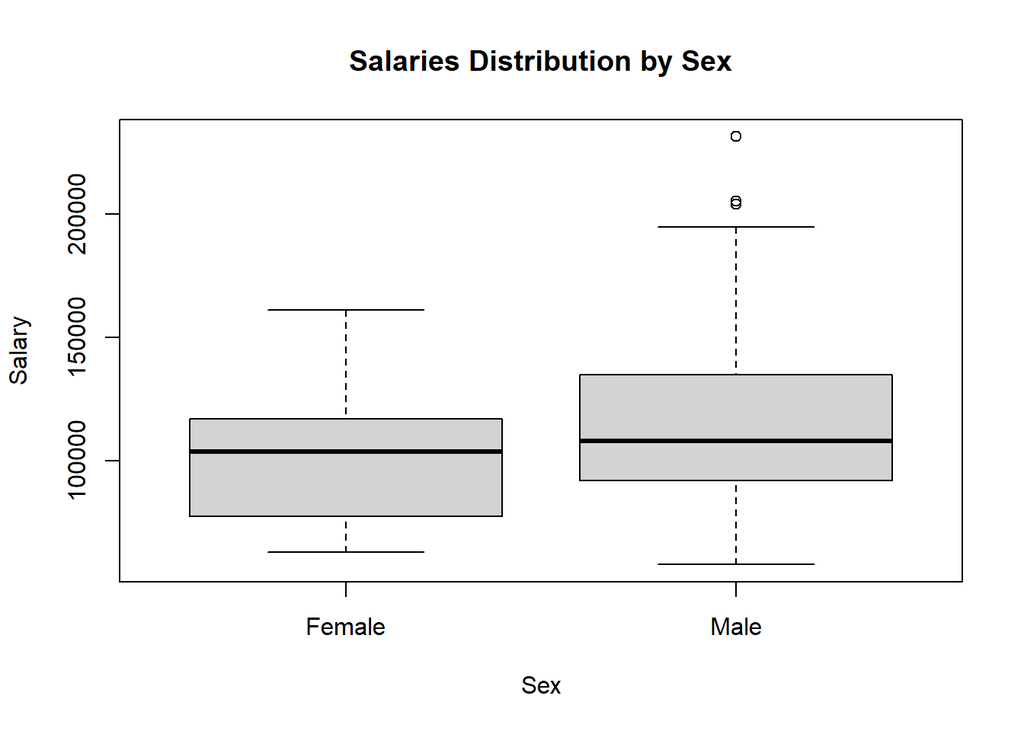

```r
boxplot(salary~sex,data = Salaries,xlab = "Sex",ylab = "Salary",main="Salaries Distribution by Sex")
```

```r
with(Salaries,by(salary,sex,median))
```

```
## sex: Female
## [1] 103750
## ------------------------------------------------------------
## sex: Male
## [1] 108043
```

```r
with(Salaries,by(salary,sex,mean))
```

```
## sex: Female
## [1] 101002.4
## ------------------------------------------------------------
## sex: Male
## [1] 115090.4
```

The medians of male and female salaries are very closed, but the means of male and female salaries are obviously different.

Use **Wilcoxon test** to do significance test. In this case, we don’t have to known the exact distribution of salary by sex.

H0:There is no statistically significant difference between female and male salaries.

H1:There is statistically significant difference between female and male salaries.

```r
wilcox.test(salary~sex,data = Salaries,conf.level=0.95)
```

```
##
##  Wilcoxon rank sum test with continuity correction
##
## data:  salary by sex
## W = 5182.5, p-value = 0.008237
## alternative hypothesis: true location shift is not equal to 0
```

p-value<0.05, so we can reject H0 at 95% confidence interval. There is statistically significant difference between female and male salaries!

## Question (3)

In this question , I classify salary by rank into 6 categories.

```r
mystats<-function(x){
  m<-mean(x)
  n<-length(x)
  s<-sd(x)
  skew<-sum((x-m)^3/s^3)/n
  kurt<-sum((x-m)^4/s^4)/n-3
  return(c(n=n,mean=m,stdev=s,skew=skew,kurtosis=kurt))
  }#function to calculate mean, standard deviation, skewness and kurtosis.
```

**1. rank=Prof,discipline=A**

```r
dataPA<-data.frame(SalaryPA=Salaries$salary[Salaries$rank=="Prof" & Salaries$discipline=="A"])
mystats(dataPA$SalaryPA)
```

```
##            n         mean        stdev         skew     kurtosis
## 1.310000e+02 1.199483e+05 2.796015e+04 8.172438e-01 4.746125e-01
```

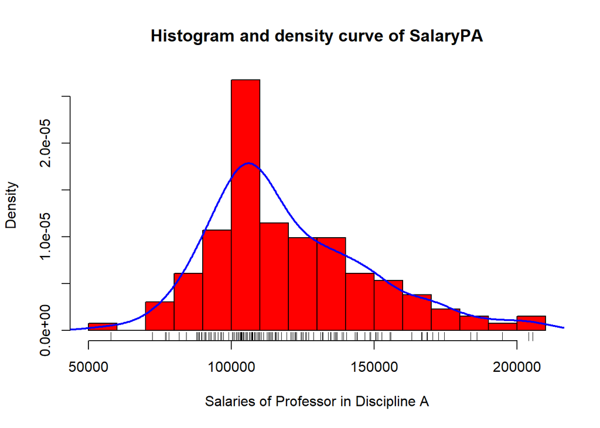

```r
h1<-hist(dataPA$SalaryPA,
          breaks = 12,
         freq = FALSE,
          col = "red",
         xlab = "Salaries of Professor in Discipline A",
         main = "Histogram and density curve of SalaryPA")
rug(jitter(dataPA$SalaryPA))
lines(density(dataPA$SalaryPA),col="blue",lwd=2)
```

From the plot, it looks like a normal distribution. Use **Kolmogorov-Smirnov test** to test the significance.

H0: SalaryPA has the same distribution as normal distribution with mean 119948 and standard deviation 27960.15.

H1: SalaryPA doesn’t have the same distribution as normal distribution with mean 119948 and standard deviation 27960.15.

(The original hypothesis and alternative hypothesis of Kolmogorov-Smirnov test below are similar as this one.)

```r
ks.test(jitter(dataPA$SalaryPA),pnorm,mean(dataPA$SalaryPA),sd(dataPA$SalaryPA))
```

```
##
##  One-sample Kolmogorov-Smirnov test
##
## data:  jitter(dataPA$SalaryPA)
## D = 0.11629, p-value = 0.05785
## alternative hypothesis: two-sided
```

p-value >0.05, can’t reject H0 at 95% confidence interval. SalaryPA follows normal distribution with mean 119948 and standard deviation 27960.15.

**2. rank=Prof,discipline=B**

```r
dataPB<-data.frame(SalaryPB=Salaries$salary[Salaries$rank=="Prof" & Salaries$discipline=="B"])
mystats(dataPB$SalaryPB)
```

```
##            n         mean        stdev         skew     kurtosis
## 1.350000e+02 1.333938e+05 2.590983e+04 5.368502e-01 6.365506e-01
```

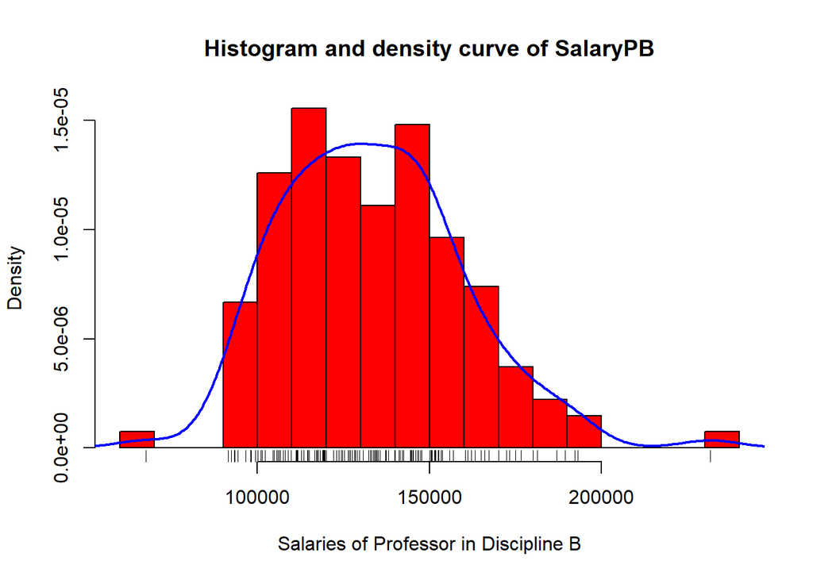

```r
h2<-hist(dataPB$SalaryPB,
         breaks = 12,
         freq = FALSE,
         col = "red",
         xlab = "Salaries of Professor in Discipline B",
         main = "Histogram and density curve of SalaryPB")
rug(jitter(dataPB$SalaryPB))
lines(density(dataPB$SalaryPB),col="blue",lwd=2)
```

From the plot, it looks like a normal distribution. Use **Kolmogorov-Smirnov test** to test the significance.

```r
ks.test(jitter(dataPB$SalaryPB),pnorm,mean(dataPB$SalaryPB),sd(dataPB$SalaryPB))
```

```
##
##  One-sample Kolmogorov-Smirnov test
##
## data:  jitter(dataPB$SalaryPB)
## D = 0.052912, p-value = 0.8441
## alternative hypothesis: two-sided
```

p-value>0.05, can’t reject H0 at 95% confidence interval. SalaryPB follows normal distribution with mean 133393.8 and standard deviation 25909.83.

**3. rank=AssocProf,discipline=A**

```r
dataAssocA<-data.frame(SalaryAssocA=Salaries$salary[Salaries$rank=="AssocProf" & Salaries$discipline=="A"])
mystats(dataAssocA$SalaryAssocA)
```

```
##            n         mean        stdev         skew     kurtosis
## 2.600000e+01 8.306112e+04 1.105052e+04 7.300816e-01 9.616243e-03
```

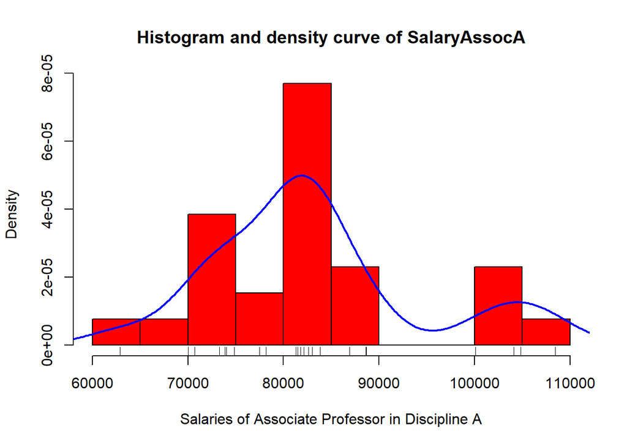

```r
h3<-hist(dataAssocA$SalaryAssocA,
         breaks = 12,
         freq = FALSE,
         col = "red",
         xlab = "Salaries of Associate Professor in Discipline A",
         main = "Histogram and density curve of SalaryAssocA")
rug(jitter(dataAssocA$SalaryAssocA))
lines(density(dataAssocA$SalaryAssocA),col="blue",lwd=2)
```

Although it doesn’t much look like a normal distribution, we can still use **Kolmogorov-Smirnov test** to test the significance.

```r
ks.test(jitter(dataAssocA$SalaryAssocA),pnorm,mean(dataAssocA$SalaryAssocA),sd(dataAssocA$SalaryAssocA))
```

```
##
##  One-sample Kolmogorov-Smirnov test
##
## data:  jitter(dataAssocA$SalaryAssocA)
## D = 0.20261, p-value = 0.206
## alternative hypothesis: two-sided
```

**4. rank=AssocProf,discipline=B**

```r
dataAssocB<-data.frame(SalaryAssocB=Salaries$salary[Salaries$rank=="AssocProf" & Salaries$discipline=="B"])
mystats(dataAssocB$SalaryAssocB)
```

```
##             n          mean         stdev          skew      kurtosis
##     38.000000 101276.394737  10237.641038     -0.221466      1.056112
```

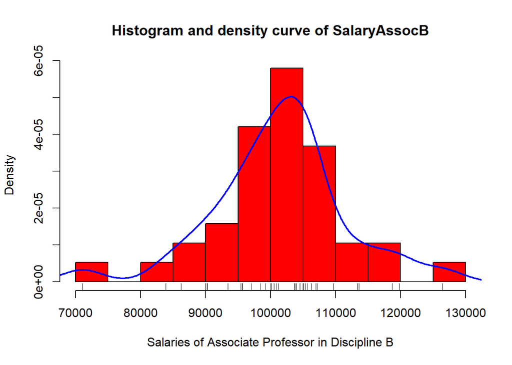

```r
h4<-hist(dataAssocB$SalaryAssocB,
         breaks = 12,
         freq = FALSE,
         col = "red",
         xlab = "Salaries of Associate Professor in Discipline B",
         main = "Histogram and density curve of SalaryAssocB")
rug(jitter(dataAssocB$SalaryAssocB))
lines(density(dataAssocB$SalaryAssocB),col="blue",lwd=2)
```

From the plot, it looks like a normal distribution. Use **Kolmogorov-Smirnov test** to test the significance.

```r
ks.test(jitter(dataAssocB$SalaryAssocB),pnorm,mean(dataAssocB$SalaryAssocB),sd(dataAssocB$SalaryAssocB))
```

```
##
##  One-sample Kolmogorov-Smirnov test
##
## data:  jitter(dataAssocB$SalaryAssocB)
## D = 0.12519, p-value = 0.5488
## alternative hypothesis: two-sided
```

p-value>0.05, can’t reject H0 at 95% confidence interval. SalaryAssocB follows normal distribution with mean 101276.394737 and standard deviation 10237.641038.

**5. rank=AsstProf,discipline=A**

```r
dataAsstA<-data.frame(SalaryAsstA=Salaries$salary[Salaries$rank=="AsstProf" & Salaries$discipline=="A"])
mystats(dataAsstA$SalaryAsstA)
```

```
##             n          mean         stdev          skew      kurtosis
##    24.0000000 73935.5416667  4726.8292799    -0.1858242     0.6361056
```

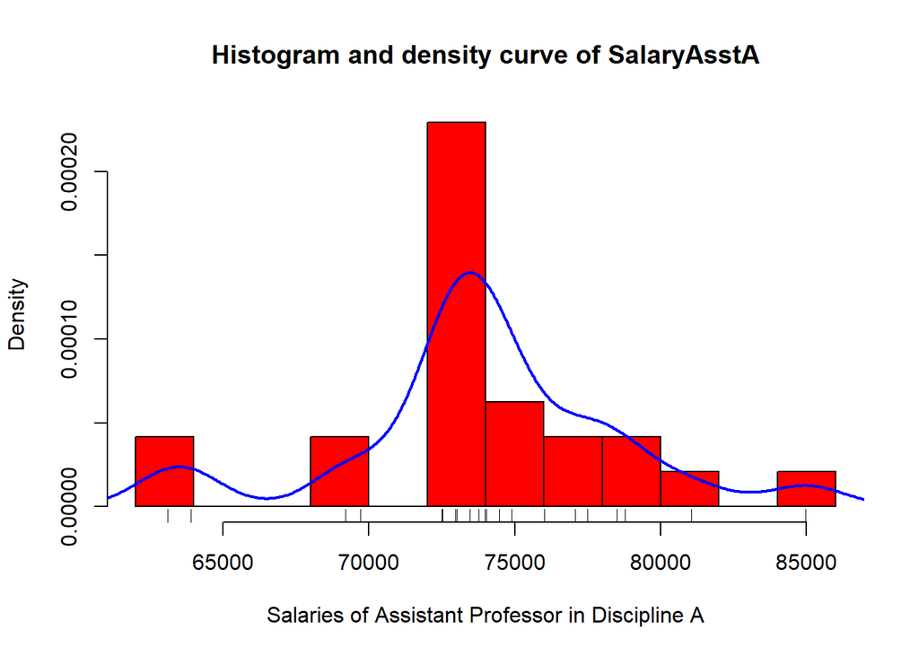

```r
h5<-hist(dataAsstA$SalaryAsstA,
         breaks = 12,
         freq = FALSE,
         col = "red",
         xlab = "Salaries of Assistant Professor in Discipline A",
         main = "Histogram and density curve of SalaryAsstA")
rug(jitter(dataAsstA$SalaryAsstA))
lines(density(dataAsstA$SalaryAsstA),col="blue",lwd=2)
```

From the plot, it looks like a normal distribution. Use **Kolmogorov-Smirnov test** to test the significance.

```r
ks.test(jitter(dataAsstA$SalaryAsstA),pnorm,mean(dataAsstA$SalaryAsstA),sd(dataAsstA$SalaryAsstA))
```

```
##
##  One-sample Kolmogorov-Smirnov test
##
## data:  jitter(dataAsstA$SalaryAsstA)
## D = 0.21401, p-value = 0.1917
## alternative hypothesis: two-sided
```

p-value>0.05, can’t reject H0 at 95% confidence interval. SalaryAsstA follows normal distribution with mean 73935.5416667 and standard deviation 4726.8292799.

**6. rank=AsstProf,discipline=B**

```r
dataAsstB<-data.frame(SalaryAsstB=Salaries$salary[Salaries$rank=="AsstProf" & Salaries$discipline=="B"])
mystats(dataAsstB$SalaryAsstB)
```

```
##             n          mean         stdev          skew      kurtosis
##    43.0000000 84593.9069767  7148.4031344    -0.3421878    -0.9573709
```

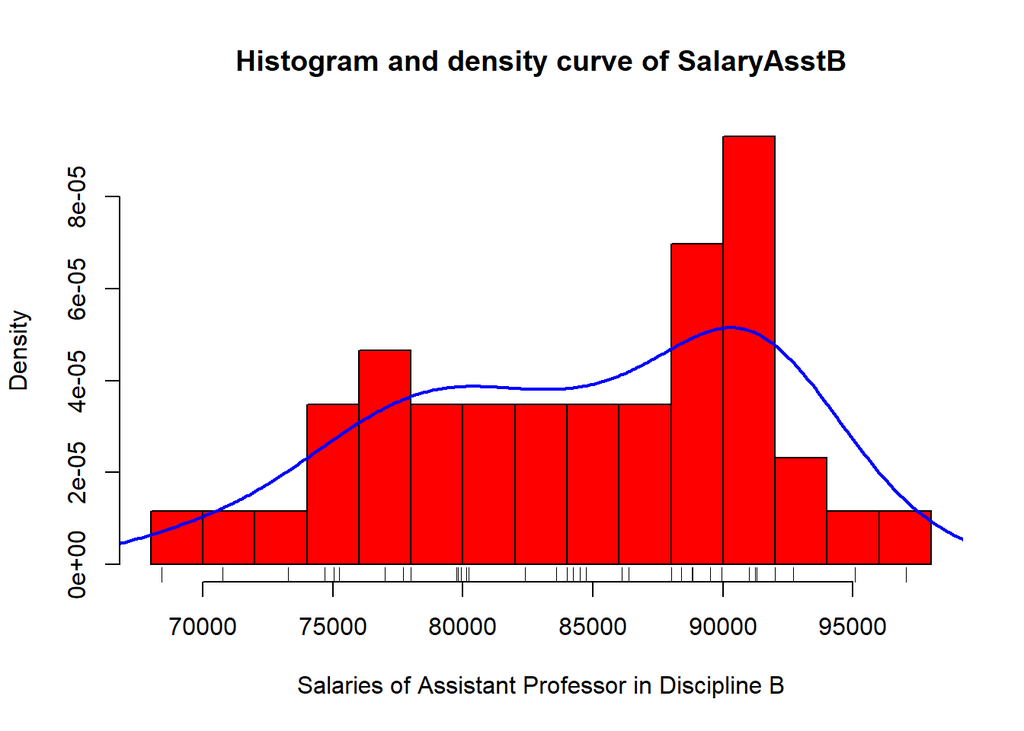

```r
h6<-hist(dataAsstB$SalaryAsstB,
         breaks = 12,
         freq = FALSE,
         col = "red",
         xlab = "Salaries of Assistant Professor in Discipline B",
         main = "Histogram and density curve of SalaryAsstB")
rug(jitter(dataAsstB$SalaryAsstB))
lines(density(dataAsstB$SalaryAsstB),col="blue",lwd=2)
```

Although it doesn’t much look like a normal distribution, we can still use **Kolmogorov-Smirnov test** to test the significance.

```r
ks.test(jitter(dataAsstB$SalaryAsstB),pnorm,mean(dataAsstB$SalaryAsstB),sd(dataAsstB$SalaryAsstB))
```

```
##
##  One-sample Kolmogorov-Smirnov test
##
## data:  jitter(dataAsstB$SalaryAsstB)
## D = 0.1249, p-value = 0.4757
## alternative hypothesis: two-sided
```

p-value>0.05, can’t reject H0 at 95% confidence interval. SalaryAsstB follows normal distribution with mean 84593.9069767 and standard deviation 7148.4031344.

## Question (4)

```r
SalariesQ4<-Salaries
SalariesQ4$discipline1[Salaries$discipline=="A"]<-0
SalariesQ4$discipline1[Salaries$discipline=="B"]<-1
SalariesQ4$discipline1<-as.factor(SalariesQ4$discipline1)
SalariesQ4[15:25,]
```

```
##         rank discipline yrs.since.phd yrs.service    sex salary discipline1
## 15      Prof          B            20          18   Male 104800           1
## 16      Prof          B            12           3   Male 117150           1
## 17      Prof          B            19          20   Male 101000           1
## 18      Prof          A            38          34   Male 103450           0
## 19      Prof          A            37          23   Male 124750           0
## 20      Prof          A            39          36 Female 137000           0
## 21      Prof          A            31          26   Male  89565           0
## 22      Prof          A            36          31   Male 102580           0
## 23      Prof          A            34          30   Male  93904           0
## 24      Prof          A            24          19   Male 113068           0
## 25 AssocProf          A            13           8 Female  74830           0
```

# Model Building 1

```r
Salaries1<-Salaries[,!names(Salaries) %in% c("discipline","sex")]
Salaries1$sex1[Salaries$sex=="Male"]<-0
Salaries1$sex1[Salaries$sex=="Female"]<-1#Male:0, Female:1
Salaries1$discipline1[Salaries$discipline=="A"]<-0
Salaries1$discipline1[Salaries$discipline=="B"]<-1#Theoretical:0, Applied:1
```

```r
dummyrank <- model.matrix(~rank, Salaries1)#transform rank into dummy variables
```

```r
Salaries1<-data.frame(dummyrank[,-1],Salaries1[,!names(Salaries1) %in% c("rank")])
Salaries1[310:320,]
```

```
##     rankAsstProf rankProf yrs.since.phd yrs.service salary sex1 discipline1
## 310            0        1            22          15 166800    0           0
## 311            0        1            20           7  92050    0           0
## 312            0        1            14           9 108100    0           0
## 313            0        1            29          19  94350    0           0
## 314            0        1            35          35 100351    0           0
## 315            0        1            22           6 146800    0           0
## 316            1        0             6           3  84716    0           1
## 317            0        0            12           9  71065    1           1
## 318            0        1            46          45  67559    0           1
## 319            0        1            16          16 134550    0           1
## 320            0        1            16          15 135027    0           1
```

```r
library(car)
```

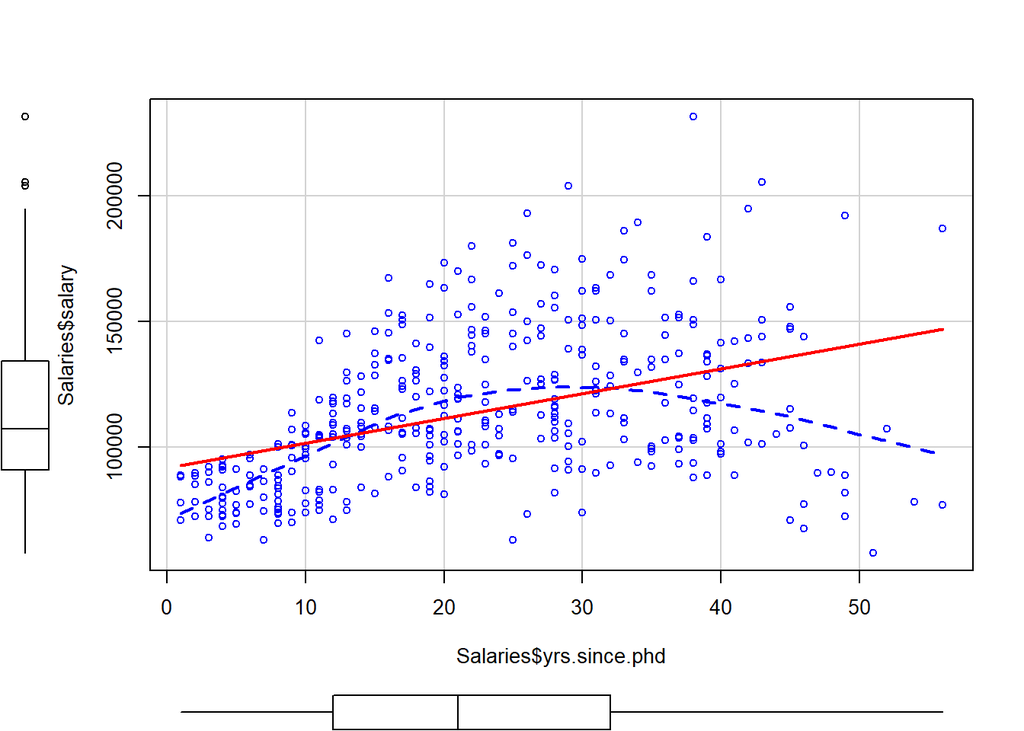

```r
scatterplot(x=Salaries$yrs.since.phd,y=Salaries$salary,smooth=list(spread=FALSE),regLine=list(lty2=2,col = "red"))
```

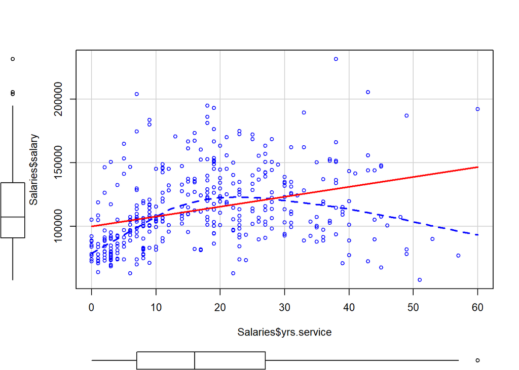

```r
scatterplot(x=Salaries$yrs.service,y=Salaries$salary,smooth=list(spread=FALSE),regLine=list(lty2=2,col = "red"))
```

From the scatter plot, we can see that salaries changed by years of service and by years since PhD was first received are very similar. They are both going up at first and down afterward.

```r
cor(Salaries1)
```

```
##               rankAsstProf   rankProf yrs.since.phd yrs.service     salary
## rankAsstProf    1.00000000 -0.6420748    -0.6025134  -0.5287015 -0.4905018
## rankProf       -0.64207477  1.0000000     0.6627194   0.5705716  0.6154579
## yrs.since.phd  -0.60251340  0.6627194     1.0000000   0.9096491  0.4192311
## yrs.service    -0.52870151  0.5705716     0.9096491   1.0000000  0.3347447
## salary         -0.49050177  0.6154579     0.4192311   0.3347447  1.0000000
## sex1            0.09983008 -0.1463468    -0.1487878  -0.1537396 -0.1386102
## discipline1     0.08839867 -0.1046061    -0.2180873  -0.1645987  0.1560839
##                       sex1  discipline1
## rankAsstProf   0.099830076  0.088398673
## rankProf      -0.146346804 -0.104606139
## yrs.since.phd -0.148787792 -0.218087325
## yrs.service   -0.153739575 -0.164598697
## salary        -0.138610169  0.156083946
## sex1           1.000000000 -0.003723739
## discipline1   -0.003723739  1.000000000
```

## Linear regression model

```r
set.seed(1234)#get train data and test data
train<-sample(nrow(Salaries1),0.7*nrow(Salaries1))
df.train<-Salaries1[train,]
df.validate<-Salaries1[-train,]
```

```r
nrow(df.train)#number of train data
```

```
## [1] 277
```

```r
nrow(df.validate)#number of test data
```

```
## [1] 120
```

```r
fit_all<-lm(salary~., data = df.train)
summary(fit_all)
```

```
##
## Call:
## lm(formula = salary ~ ., data = df.train)
##
## Residuals:
##    Min     1Q Median     3Q    Max
## -65548 -12377  -1590  10234  87043
##
## Coefficients:
##                Estimate Std. Error t value Pr(>|t|)
## (Intercept)    85944.84    4275.26  20.103  < 2e-16 ***
## rankAsstProf  -13659.53    4674.11  -2.922  0.00377 **
## rankProf       32223.84    4048.42   7.960 4.80e-14 ***
## yrs.since.phd    -65.06     280.09  -0.232  0.81651
## yrs.service       96.48     243.58   0.396  0.69234
## sex1           -1845.75    4685.81  -0.394  0.69396
## discipline1    13588.68    2677.96   5.074 7.25e-07 ***
## ---
## Signif. codes:  0 '***' 0.001 '**' 0.01 '*' 0.05 '.' 0.1 ' ' 1
##
## Residual standard error: 21530 on 270 degrees of freedom
## Multiple R-squared:  0.4505, Adjusted R-squared:  0.4383
## F-statistic:  36.9 on 6 and 270 DF,  p-value: < 2.2e-16
```

The median of residuals is -1590, which is too large! It means there could be excessive error in the regression model.

The p-value of F-statistic to this linear regression model is less than 2.2e-16, so the regression model is very significant.

From coefficients, we can see that there are only 3 variables are significant: rankAsstProf, rankProf and discipline1.

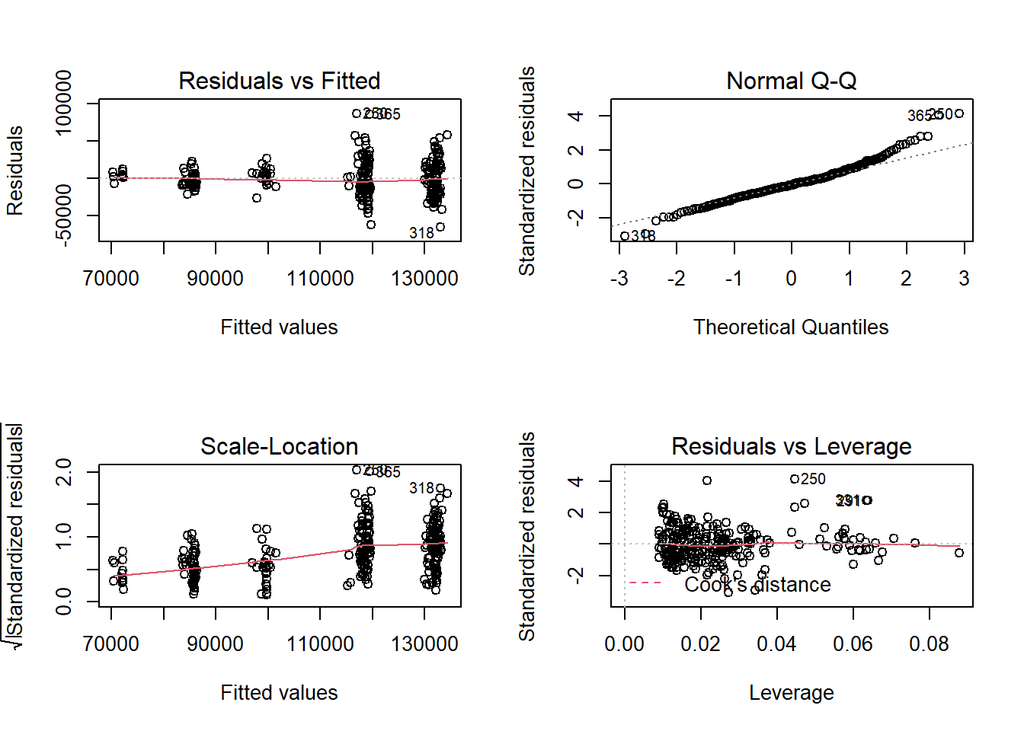

```r
opar <- par(mfrow=c(1,1))
par(mfrow=c(2,2))
plot(fit_all)
```

1)“Residuals vs Fitted”: Observations of the error term are obviously uncorrelated with each other.

2)“Normal Q-Q”：If residuals follow standard normal distribution, then they should follow the straight line on the graph. They look good on the plot!

4)“Residuals vs Leverage”：On this plot, we can see 3 outliers.

Overall, the regression model is good according to those diagnosis graphs.

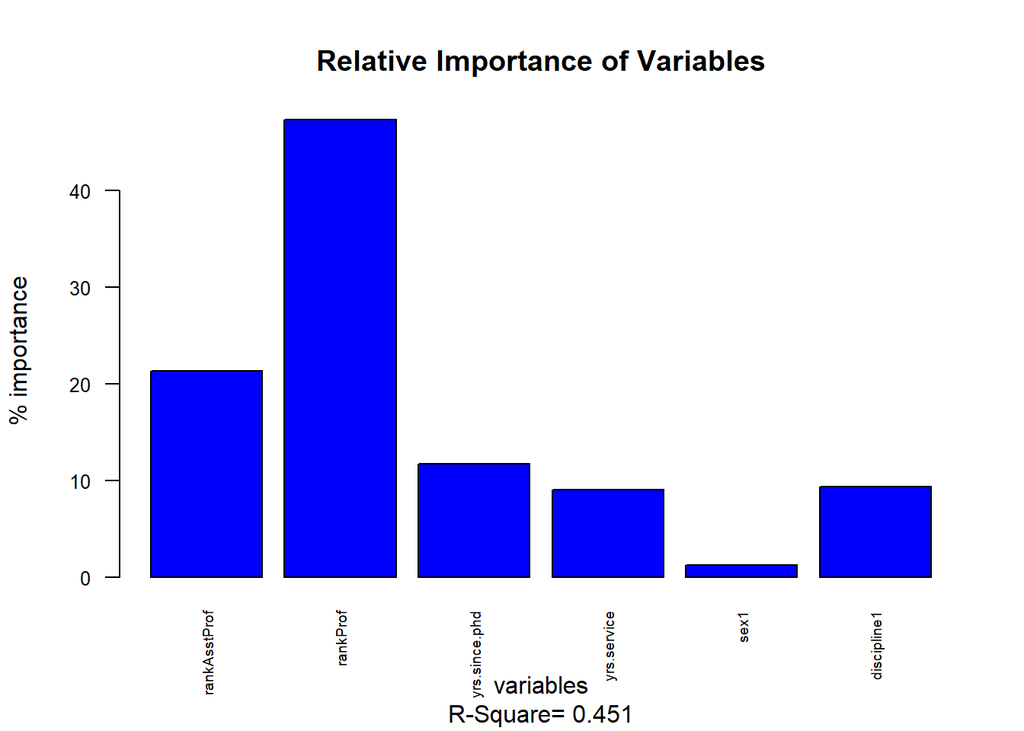

```
##                 Weights
## rankAsstProf  21.296145
## rankProf      47.332581
## yrs.since.phd 11.722622
## yrs.service    9.028302
## sex1           1.254236
## discipline1    9.366114
```

```r
relweights <-function(fit,...){
    R <- cor(fit$model)
    nvar <- ncol(R)
    rxx <- R[2:nvar, 2:nvar]
    rxy <- R[2:nvar, 1]
    svd <- eigen(rxx)
    evec <- svd$vectors
    ev <- svd$values
    delta <- diag(sqrt(ev))
    lambda <- evec %*% delta %*% t(evec)
    lambdasq <- lambda ^ 2
    beta <- solve(lambda) %*% rxy
    rsquare <- colSums(beta ^ 2)
    rawwgt <- lambdasq %*% beta ^ 2
    import <- (rawwgt / rsquare) * 100
    lbls <- names(fit$model[2:nvar])
    rownames(import) <- lbls
    colnames(import) <- "Weights"
    import
    barplot(t(import),names.arg=lbls,
            ylab="% importance",
            xlab="variables",
            width=0.2,
            cex.axis = 0.8,
            cex.names = 0.6,
            las=2,
            main="Relative Importance of Variables",
            sub=paste("R-Square=", round(rsquare, digits=3)),
            ...)
    return(import)
}#view the relative importance of each variable
par(opar)
relweights(fit_all,col="blue")
```

Whether it is a professor is the most important factor to salary, while sex is the least important factor.

```r
vif(fit_all)
```

```
##  rankAsstProf      rankProf yrs.since.phd   yrs.service          sex1
##      1.744501      2.172682      7.688571      6.165869      1.038404
##   discipline1
##      1.052332
```

```r
sqrt(vif(fit_all))>2#test multicollinearity
```

```
##  rankAsstProf      rankProf yrs.since.phd   yrs.service          sex1
##         FALSE         FALSE          TRUE          TRUE         FALSE
##   discipline1
##         FALSE
```

There is a multicollinearity between yrs.since.phd and yrs.service. Their VIFs are near 7, and the multicollinearity can’t be ignored. There are two ways to reduce the impact of multicollinearity: stepwise regression and ridge regression.

## Backward stepwise regression

```r
reduced.model<-step(fit_all,direction = "backward")
```

```
## Start:  AIC=5534.26
## salary ~ rankAsstProf + rankProf + yrs.since.phd + yrs.service +
##     sex1 + discipline1
##
##                 Df  Sum of Sq        RSS    AIC
## - yrs.since.phd  1 2.5005e+07 1.2517e+11 5532.3
## - sex1           1 7.1917e+07 1.2522e+11 5532.4
## - yrs.service    1 7.2725e+07 1.2522e+11 5532.4
## <none>                        1.2515e+11 5534.3
## - rankAsstProf   1 3.9585e+09 1.2911e+11 5540.9
## - discipline1    1 1.1934e+10 1.3708e+11 5557.5
## - rankProf       1 2.9366e+10 1.5451e+11 5590.6
##
## Step:  AIC=5532.31
## salary ~ rankAsstProf + rankProf + yrs.service + sex1 + discipline1
##
##                Df  Sum of Sq        RSS    AIC
## - yrs.service   1 6.8405e+07 1.2524e+11 5530.5
## - sex1          1 7.7333e+07 1.2525e+11 5530.5
## <none>                       1.2517e+11 5532.3
## - rankAsstProf  1 3.9555e+09 1.2913e+11 5538.9
## - discipline1   1 1.2323e+10 1.3750e+11 5556.3
## - rankProf      1 3.2321e+10 1.5749e+11 5593.9
##
## Step:  AIC=5530.47
## salary ~ rankAsstProf + rankProf + sex1 + discipline1
##
##                Df  Sum of Sq        RSS    AIC
## - sex1          1 8.5858e+07 1.2533e+11 5528.7
## <none>                       1.2524e+11 5530.5
## - rankAsstProf  1 4.3648e+09 1.2960e+11 5538.0
## - discipline1   1 1.2261e+10 1.3750e+11 5554.3
## - rankProf      1 3.9805e+10 1.6504e+11 5604.9
##
## Step:  AIC=5528.66
## salary ~ rankAsstProf + rankProf + discipline1
##
##                Df  Sum of Sq        RSS    AIC
## <none>                       1.2533e+11 5528.7
## - rankAsstProf  1 4.4546e+09 1.2978e+11 5536.3
## - discipline1   1 1.2295e+10 1.3762e+11 5552.6
## - rankProf      1 4.0524e+10 1.6585e+11 5604.3
```

```r
summary(reduced.model)
```

```
##
## Call:
## lm(formula = salary ~ rankAsstProf + rankProf + discipline1,
##     data = df.train)
##
## Residuals:
##    Min     1Q Median     3Q    Max
## -64486 -12345  -1824  10422  87049
##
## Coefficients:
##              Estimate Std. Error t value Pr(>|t|)
## (Intercept)     85810       3451  24.863  < 2e-16 ***
## rankAsstProf   -13980       4488  -3.115  0.00204 **
## rankProf        32641       3474   9.395  < 2e-16 ***
## discipline1     13594       2627   5.175 4.42e-07 ***
## ---
## Signif. codes:  0 '***' 0.001 '**' 0.01 '*' 0.05 '.' 0.1 ' ' 1
##
## Residual standard error: 21430 on 273 degrees of freedom
## Multiple R-squared:  0.4497, Adjusted R-squared:  0.4437
## F-statistic: 74.37 on 3 and 273 DF,  p-value: < 2.2e-16
```

```r
bwdmodel<-lm(salary~rankAsstProf+rankProf+discipline1,data = df.train)
summary(bwdmodel)
```

```
##
## Call:
## lm(formula = salary ~ rankAsstProf + rankProf + discipline1,
##     data = df.train)
##
## Residuals:
##    Min     1Q Median     3Q    Max
## -64486 -12345  -1824  10422  87049
##
## Coefficients:
##              Estimate Std. Error t value Pr(>|t|)
## (Intercept)     85810       3451  24.863  < 2e-16 ***
## rankAsstProf   -13980       4488  -3.115  0.00204 **
## rankProf        32641       3474   9.395  < 2e-16 ***
## discipline1     13594       2627   5.175 4.42e-07 ***
## ---
## Signif. codes:  0 '***' 0.001 '**' 0.01 '*' 0.05 '.' 0.1 ' ' 1
##
## Residual standard error: 21430 on 273 degrees of freedom
## Multiple R-squared:  0.4497, Adjusted R-squared:  0.4437
## F-statistic: 74.37 on 3 and 273 DF,  p-value: < 2.2e-16
```

In the backward stepwise regression model, 3 variables are omitted: yrs.since.phd, yrs.service, and sex1. Remained variables are all significant.Adjusted R-squared is 0.4437, which is a bit better than the previous regression model.

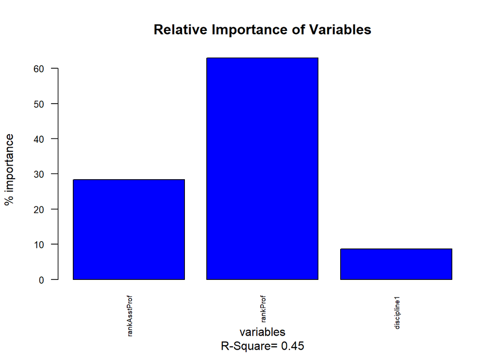

```
##                Weights
## rankAsstProf 28.374405
## rankProf     62.957260
## discipline1   8.668335
```

```r
relweights(bwdmodel,col="blue")
```

Whether it is a professor is the most important factor to salary, while discipline becomes the least important factor.

## Forward stepwise regression

```r
min.model<-lm(salary~1,data=df.train)
fwdmodel<-step(min.model,direction="forward",scope = "~rankAsstProf+rankProf+yrs.service+yrs.since.phd+discipline1+sex1",data=df.train)
```

```
## Start:  AIC=5688.12
## salary ~ 1
##
##                 Df  Sum of Sq        RSS    AIC
## + rankProf       1 8.6816e+10 1.4094e+11 5557.2
## + rankAsstProf   1 5.1500e+10 1.7625e+11 5619.1
## + yrs.since.phd  1 4.0267e+10 1.8749e+11 5636.2
## + yrs.service    1 3.2706e+10 1.9505e+11 5647.2
## + discipline1    1 4.7673e+09 2.2299e+11 5684.3
## + sex1           1 3.9069e+09 2.2385e+11 5685.3
## <none>                        2.2775e+11 5688.1
##
## Step:  AIC=5557.18
## salary ~ rankProf
##
##                 Df  Sum of Sq        RSS    AIC
## + discipline1    1 1.1158e+10 1.2978e+11 5536.3
## + rankAsstProf   1 3.3185e+09 1.3762e+11 5552.6
## <none>                        1.4094e+11 5557.2
## + sex1           1 2.0440e+08 1.4073e+11 5558.8
## + yrs.service    1 1.1630e+08 1.4082e+11 5558.9
## + yrs.since.phd  1 1.1898e+07 1.4093e+11 5559.2
##
## Step:  AIC=5536.33
## salary ~ rankProf + discipline1
##
##                 Df  Sum of Sq        RSS    AIC
## + rankAsstProf   1 4454602060 1.2533e+11 5528.7
## <none>                        1.2978e+11 5536.3
## + yrs.service    1  514944142 1.2927e+11 5537.2
## + yrs.since.phd  1  470055581 1.2931e+11 5537.3
## + sex1           1  175654729 1.2960e+11 5538.0
##
## Step:  AIC=5528.66
## salary ~ rankProf + discipline1 + rankAsstProf
##
##                 Df Sum of Sq        RSS    AIC
## <none>                       1.2533e+11 5528.7
## + sex1           1  85857550 1.2524e+11 5530.5
## + yrs.service    1  76929078 1.2525e+11 5530.5
## + yrs.since.phd  1  22141289 1.2530e+11 5530.6
```

```r
summary(fwdmodel)
```

```
##
## Call:
## lm(formula = salary ~ rankProf + discipline1 + rankAsstProf,
##     data = df.train)
##
## Residuals:
##    Min     1Q Median     3Q    Max
## -64486 -12345  -1824  10422  87049
##
## Coefficients:
##              Estimate Std. Error t value Pr(>|t|)
## (Intercept)     85810       3451  24.863  < 2e-16 ***
## rankProf        32641       3474   9.395  < 2e-16 ***
## discipline1     13594       2627   5.175 4.42e-07 ***
## rankAsstProf   -13980       4488  -3.115  0.00204 **
## ---
## Signif. codes:  0 '***' 0.001 '**' 0.01 '*' 0.05 '.' 0.1 ' ' 1
##
## Residual standard error: 21430 on 273 degrees of freedom
## Multiple R-squared:  0.4497, Adjusted R-squared:  0.4437
## F-statistic: 74.37 on 3 and 273 DF,  p-value: < 2.2e-16
```

Forward stepwise regression gets the same results as backward regression model, so I will only use the backward one to do further analysis.

## Ridge regression

Ridge regression is a method that we don’t have to omit any variable and can resolve the multicollinearity problem.

```r
library(ridge)
mod<-linearRidge(salary~.,data=df.train)
summary(mod)
```

```
##
## Call:
## linearRidge(formula = salary ~ ., data = df.train)
##
##
## Coefficients:
##                 Estimate Scaled estimate Std. Error (scaled) t value (scaled)
## (Intercept)    86480.804              NA                  NA               NA
## rankAsstProf  -13769.990      -83771.837           26505.520            3.161
## rankProf       30341.029      237831.950           28818.563            8.253
## yrs.since.phd     -1.092        -232.746           42616.433            0.005
## yrs.service       72.091       15822.065           39039.155            0.405
## sex1           -2052.999       -9612.020           21150.819            0.454
## discipline1    13190.961      108787.002           21242.139            5.121
##               Pr(>|t|)
## (Intercept)         NA
## rankAsstProf   0.00157 **
## rankProf      2.22e-16 ***
## yrs.since.phd  0.99564
## yrs.service    0.68527
## sex1           0.64950
## discipline1   3.03e-07 ***
## ---
## Signif. codes:  0 '***' 0.001 '**' 0.01 '*' 0.05 '.' 0.1 ' ' 1
##
## Ridge parameter: 0.03257342, chosen automatically, computed using 4 PCs
##
## Degrees of freedom: model 5.492 , variance 5.086 , residual 5.899
```

Since the ridge parameter is 0.03257342, which is near to 0, the ridge regression model is almost a linear regression model. There is not much improvement using ridge regression.

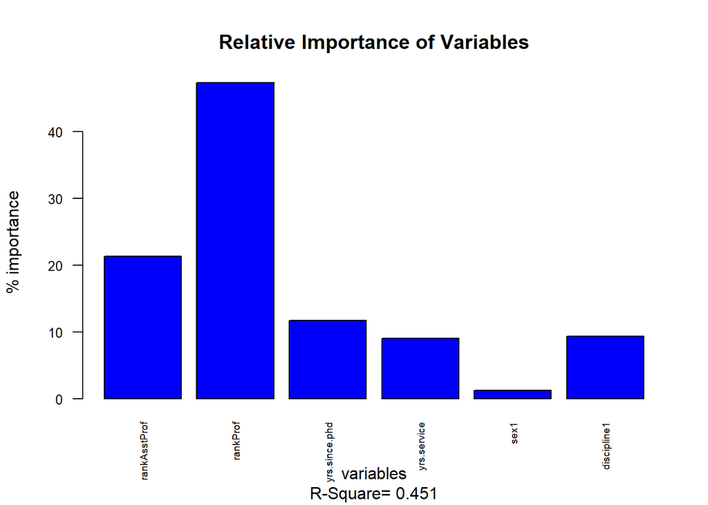

```
##                 Weights
## rankAsstProf  21.296145
## rankProf      47.332581
## yrs.since.phd 11.722622
## yrs.service    9.028302
## sex1           1.254236
## discipline1    9.366114
```

```r
relweights(mod,col="blue")
```

Whether it is a professor is the most important factor to salary, while sex is the least important factor.

## Prediction

Use root mean squard error (RMSE) to evaluate the accuracy of models above.

**1. Full regression model**

```r
lm.pred<-predict(fit_all,df.validate,type="response")
lm.perf<-data.frame(predicted=lm.pred,actual=df.validate$salary)
rmse<-sqrt((mean((lm.perf$predicted-lm.perf$actual)^2)))
rmse
```

```
## [1] 25443.05
```

The predictive value using full linear regression model is 25443.05 different from actual value on average.

**2. Stepwise regression model**

```r
bwd.pred<-predict(bwdmodel,df.validate,type="response")
bwd.perf<-data.frame(predicted=bwd.pred,actual=df.validate$salary)
brmse<-sqrt((mean((bwd.perf$predicted-bwd.perf$actual)^2)))
brmse
```

```
## [1] 25307.6
```

The predictive value using stepwise regression model is 25307.6 different from actual value on average.

**3. Ridge regression model**

```r
lr.pred<-predict(mod,df.validate,type="response")
lr.perf<-data.frame(predicted=lr.pred,actual=df.validate$salary)
lrmse<-sqrt((mean((lr.perf$predicted-lr.perf$actual)^2)))
lrmse
```

```
## [1] 25419.56
```

The predictive value using ridge regression model is 25419.56 different from actual value on average.

## Model test

**1. Salary change by rank**

```r
testdata1<-data.frame(rankAsstProf=c(0,0,1),rankProf=c(0,1,0),
                     yrs.service=mean(Salaries1$yrs.service),
                     yrs.since.phd=mean(Salaries1$yrs.since.phd),
                     discipline1=mean(Salaries1$discipline1),
                     sex1=mean(Salaries1$sex1))
testdata1$salarylm<-predict(fit_all,newdata = testdata1,type = "response")
testdata1$salarybw<-predict(bwdmodel,newdata = testdata1,type = "response")
testdata1$salarylr<-predict(mod,newdata = testdata1,type = "response")
testdata1
```

```
##   rankAsstProf rankProf yrs.service yrs.since.phd discipline1       sex1
## 1            0        0    17.61461      22.31486   0.5440806 0.09823678
## 2            0        1    17.61461      22.31486   0.5440806 0.09823678
## 3            1        0    17.61461      22.31486   0.5440806 0.09823678
##    salarylm  salarybw  salarylr
## 1  93404.65  93206.19  94701.55
## 2 125628.49 125847.11 125042.58
## 3  79745.12  79226.48  80931.56
```

In the full linear regression model, fixed other factors, when rank changes from assistant professor to associate professor, salary increases from 79745.12 to 93404.65; when rank changes from associate professor to professor, salary increases to 125628.49.

Similar description could be applied to stepwise regression model and ridge regression model.

**2. Salary change by years service**

```r
testdata2<-data.frame(rankAsstProf=mean(Salaries1$rankAsstProf),rankProf=mean(Salaries1$rankProf),
                      yrs.service=seq(1,60,10),
                      yrs.since.phd=mean(Salaries1$yrs.since.phd),
                      discipline1=mean(Salaries1$discipline1),
                      sex1=mean(Salaries1$sex1))
testdata2$salarylm<-predict(fit_all,newdata = testdata2,type = "response")
testdata2$salarybw<-predict(bwdmodel,newdata = testdata2,type = "response")
testdata2$salarylr<-predict(mod,newdata = testdata2,type = "response")
testdata2
```

```
##   rankAsstProf  rankProf yrs.service yrs.since.phd discipline1       sex1
## 1    0.1687657 0.6700252           1      22.31486   0.5440806 0.09823678
## 2    0.1687657 0.6700252          11      22.31486   0.5440806 0.09823678
## 3    0.1687657 0.6700252          21      22.31486   0.5440806 0.09823678
## 4    0.1687657 0.6700252          31      22.31486   0.5440806 0.09823678
## 5    0.1687657 0.6700252          41      22.31486   0.5440806 0.09823678
## 6    0.1687657 0.6700252          51      22.31486   0.5440806 0.09823678
##   salarylm salarybw salarylr
## 1 111087.1 112717.1 111509.1
## 2 112052.0 112717.1 112230.0
## 3 113016.8 112717.1 112951.0
## 4 113981.6 112717.1 113671.9
## 5 114946.5 112717.1 114392.8
## 6 115911.3 112717.1 115113.7
```

In the full linear regression model, fixed other factors, salary increases around 1000 per decade, which is not fit the scatter plot we got before.

Similar description could be applied to ridge regression model, with an increasing of around 700 per decade.

It is noticeable that salary remains 112717.1 in the stepwise regression model. Because this model omit variable ys.service, so the change of it will not be reflected in the regression result.

**3. Salary change by years since PhD was first received**

```r
testdata3<-data.frame(rankAsstProf=mean(Salaries1$rankAsstProf),rankProf=mean(Salaries1$rankProf),
                      yrs.service=mean(Salaries1$yrs.service),
                      yrs.since.phd=seq(1,56,10),
                      discipline1=mean(Salaries1$discipline1),
                      sex1=mean(Salaries1$sex1))
testdata3$salarylm<-predict(fit_all,newdata = testdata3,type = "response")
testdata3$salarybw<-predict(bwdmodel,newdata = testdata3,type = "response")
testdata3$salarylr<-predict(mod,newdata = testdata3,type = "response")
testdata3
```

```
##   rankAsstProf  rankProf yrs.service yrs.since.phd discipline1       sex1
## 1    0.1687657 0.6700252    17.61461             1   0.5440806 0.09823678
## 2    0.1687657 0.6700252    17.61461            11   0.5440806 0.09823678
## 3    0.1687657 0.6700252    17.61461            21   0.5440806 0.09823678
## 4    0.1687657 0.6700252    17.61461            31   0.5440806 0.09823678
## 5    0.1687657 0.6700252    17.61461            41   0.5440806 0.09823678
## 6    0.1687657 0.6700252    17.61461            51   0.5440806 0.09823678
##   salarylm salarybw salarylr
## 1 114076.8 112717.1 112730.2
## 2 113426.3 112717.1 112719.3
## 3 112775.7 112717.1 112708.3
## 4 112125.1 112717.1 112697.4
## 5 111474.6 112717.1 112686.5
## 6 110824.0 112717.1 112675.6
```

In the full linear regression model, fixed other factors, salary decreases around 600 per decade, which is not fit the scatter plot we got before.

Similar description could be applied to ridge regression model, with a decreasing of around 10 per decade.

It is noticeable that salary remains 112717.1 in the stepwise regression model. Because this model omit variable ys.since.phd, so the change of it will not be reflected in the regression result.

**4. Salary change by discipline**

```r
testdata4<-data.frame(rankAsstProf=mean(Salaries1$rankAsstProf),rankProf=mean(Salaries1$rankProf),
                      yrs.service=mean(Salaries1$yrs.service),
                      yrs.since.phd=mean(Salaries1$yrs.since.phd),
                      discipline1=c(0,1),
                      sex1=mean(Salaries1$sex1))
testdata4$salarylm<-predict(fit_all,newdata = testdata4,type = "response")
testdata4$salarybw<-predict(bwdmodel,newdata = testdata4,type = "response")
testdata4$salarylr<-predict(mod,newdata = testdata4,type = "response")
testdata4
```

```
##   rankAsstProf  rankProf yrs.service yrs.since.phd discipline1       sex1
## 1    0.1687657 0.6700252    17.61461      22.31486           0 0.09823678
## 2    0.1687657 0.6700252    17.61461      22.31486           1 0.09823678
##   salarylm salarybw salarylr
## 1 105296.8 105321.2 105530.0
## 2 118885.5 118914.7 118720.9
```

In the full linear regression model, fixed other factors, when discipline changes from theoretical department to applied department, salary increases from 105296.8 to 118885.5.

Similar description could be applied to stepwise regression model and ridge regression model.

**5. Salary change by sex**

```r
testdata5<-data.frame(rankAsstProf=mean(Salaries1$rankAsstProf),rankProf=mean(Salaries1$rankProf),
                      yrs.service=mean(Salaries1$yrs.service),
                      yrs.since.phd=mean(Salaries1$yrs.since.phd),
                      discipline1=mean(Salaries1$discipline1),
                      sex1=c(0,1))
testdata5$salarylm<-predict(fit_all,newdata = testdata5,type = "response")
testdata5$salarybw<-predict(bwdmodel,newdata = testdata5,type = "response")
testdata5$salarylr<-predict(mod,newdata = testdata5,type = "response")
testdata5
```

```
##   rankAsstProf  rankProf yrs.service yrs.since.phd discipline1 sex1 salarylm
## 1    0.1687657 0.6700252    17.61461      22.31486   0.5440806    0 112871.5
## 2    0.1687657 0.6700252    17.61461      22.31486   0.5440806    1 111025.7
##   salarybw salarylr
## 1 112717.1 112908.6
## 2 112717.1 110855.6
```

In the full linear regression model, fixed other factors, when sex changes from male to female, salary decreases from 112871.5 to 111025.7.

Similar description could be applied to ridge regression model.

It is noticeable that salary remains 112717.1 in the stepwise regression model. Because this model omit variable sex, so the change of it will not be reflected in the regression result.

# Model Building 2

```r
Salaries2<-Salaries[,!names(Salaries) %in% c("salary")]
Salaries2$bisalary[Salaries$salary<median(Salaries$salary)]<-0
Salaries2$bisalary[Salaries$salary>=median(Salaries$salary)]<-1
Salaries2[1:10,]#transform salary in to 0/1 binary indicator
```

```
##         rank discipline yrs.since.phd yrs.service    sex bisalary
## 1       Prof          B            19          18   Male        1
## 2       Prof          B            20          16   Male        1
## 3   AsstProf          B             4           3   Male        0
## 4       Prof          B            45          39   Male        1
## 5       Prof          B            40          41   Male        1
## 6  AssocProf          B             6           6   Male        0
## 7       Prof          B            30          23   Male        1
## 8       Prof          B            45          45   Male        1
## 9       Prof          B            21          20   Male        1
## 10      Prof          B            18          18 Female        1
```

```r
set.seed(1234)#get train data and test data
ntrain<-sample(nrow(Salaries2),0.7*nrow(Salaries2))
ndf.train<-Salaries2[ntrain,]
ndf.validate<-Salaries2[-ntrain,]
```

```r
table(ndf.train$bisalary)#component of train data
```

```
##
##   0   1
## 139 138
```

```r
table(ndf.validate$bisalary)#component of test data
```

```
##
##  0  1
## 59 61
```

## Logistic regression

```r
glmmodel<-glm(bisalary~.,data=ndf.train,family = binomial)
summary(glmmodel)
```

```
##
## Call:
## glm(formula = bisalary ~ ., family = binomial, data = ndf.train)
##
## Deviance Residuals:
##      Min        1Q    Median        3Q       Max
## -2.07287  -0.50474  -0.00007   0.66967   2.53245
##
## Coefficients:
##                Estimate Std. Error z value Pr(>|z|)
## (Intercept)    -2.02227    0.86745  -2.331 0.019739 *
## rankAsstProf  -16.75366  955.65390  -0.018 0.986013
## rankProf        3.83687    0.59701   6.427  1.3e-10 ***
## disciplineB     1.16645    0.34029   3.428 0.000608 ***
## yrs.since.phd  -0.05594    0.03203  -1.746 0.080736 .
## yrs.service     0.03409    0.02727   1.250 0.211316
## sexMale        -0.61774    0.73919  -0.836 0.403325
## ---
## Signif. codes:  0 '***' 0.001 '**' 0.01 '*' 0.05 '.' 0.1 ' ' 1
##
## (Dispersion parameter for binomial family taken to be 1)
##
##     Null deviance: 384.00  on 276  degrees of freedom
## Residual deviance: 232.97  on 270  degrees of freedom
## AIC: 246.97
##
## Number of Fisher Scoring iterations: 17
```

```r
prob<-predict(glmmodel,ndf.validate,type='response')
logit.pred<-factor(prob>0.5,levels = c(FALSE,TRUE),
                           labels = c("0","1"))
logit.perf<-table(ndf.validate$bisalary,logit.pred,
                          dnn=c("Actual","Predicted"))
logit.perf
```

```
##       Predicted
## Actual  0  1
##      0 38 21
##      1  7 54
```

## Stepwise logistic regression

```r
logit.fit.reduced<-step(glmmodel)
```

```
## Start:  AIC=246.97
## bisalary ~ rank + discipline + yrs.since.phd + yrs.service +
##     sex
##
##                 Df Deviance    AIC
## - sex            1   233.69 245.69
## - yrs.service    1   234.53 246.53
## <none>               232.97 246.97
## - yrs.since.phd  1   236.03 248.03
## - discipline     1   245.52 257.52
## - rank           2   336.13 346.13
##
## Step:  AIC=245.69
## bisalary ~ rank + discipline + yrs.since.phd + yrs.service
##
##                 Df Deviance    AIC
## - yrs.service    1   235.00 245.00
## <none>               233.69 245.69
## - yrs.since.phd  1   236.48 246.48
## - discipline     1   246.19 256.19
## - rank           2   336.38 344.38
##
## Step:  AIC=245
## bisalary ~ rank + discipline + yrs.since.phd
##
##                 Df Deviance    AIC
## - yrs.since.phd  1   236.85 244.85
## <none>               235.00 245.00
## - discipline     1   247.83 255.83
## - rank           2   336.38 342.38
##
## Step:  AIC=244.85
## bisalary ~ rank + discipline
##
##              Df Deviance    AIC
## <none>            236.85 244.85
## - discipline  1   251.85 257.85
## - rank        2   381.29 385.29
```

```r
summary(logit.fit.reduced)
```

```
##
## Call:
## glm(formula = bisalary ~ rank + discipline, family = binomial,
##     data = ndf.train)
##
## Deviance Residuals:
##      Min        1Q    Median        3Q       Max
## -1.89626  -0.56031  -0.00008   0.60183   2.47621
##
## Coefficients:
##              Estimate Std. Error z value Pr(>|z|)
## (Intercept)   -3.0181     0.5478  -5.509 3.60e-08 ***
## rankAsstProf -16.5235   956.9303  -0.017 0.986223
## rankProf       3.3890     0.5260   6.443 1.17e-10 ***
## disciplineB    1.2459     0.3346   3.723 0.000197 ***
## ---
## Signif. codes:  0 '***' 0.001 '**' 0.01 '*' 0.05 '.' 0.1 ' ' 1
##
## (Dispersion parameter for binomial family taken to be 1)
##
##     Null deviance: 384.00  on 276  degrees of freedom
## Residual deviance: 236.85  on 273  degrees of freedom
## AIC: 244.85
##
## Number of Fisher Scoring iterations: 17
```

```r
prob.reduced<-predict(logit.fit.reduced,ndf.validate,type='response')
logit.pred.reduced<-factor(prob.reduced>0.5,levels = c(FALSE,TRUE),
                           labels = c("0","1"))
logit.perf.reduced<-table(ndf.validate$bisalary,logit.pred.reduced,
                          dnn=c("Actual","Predicted"))
logit.perf.reduced
```

```
##       Predicted
## Actual  0  1
##      0 37 22
##      1  2 59
```

## Classification decision tree

```r
library(rpart)
set.seed(1234)
dtree<-rpart(bisalary~.,data = ndf.train,method = "class",
             parms = list(split="information"))
dtree$cptable
```

```
##           CP nsplit rel error    xerror       xstd
## 1 0.58695652      0 1.0000000 1.1594203 0.05957087
## 2 0.01811594      1 0.4130435 0.4130435 0.04875619
## 3 0.01630435      3 0.3768116 0.4420290 0.04997730
## 4 0.01000000      7 0.3115942 0.4927536 0.05190493
```

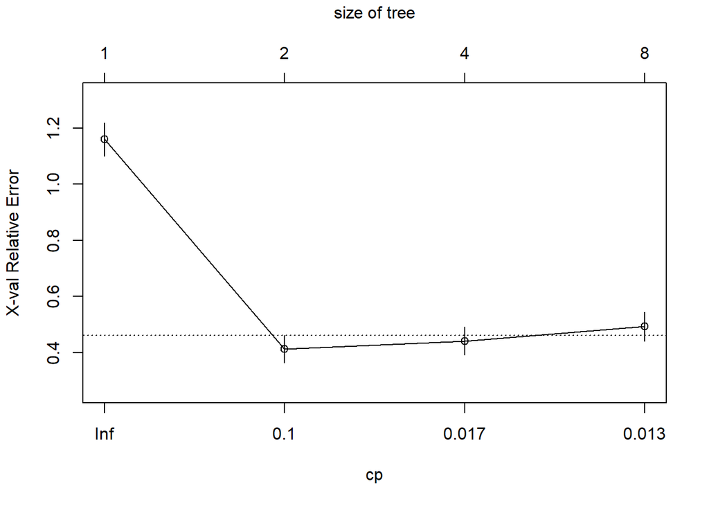

```r
par(opar)
plotcp(dtree)
```

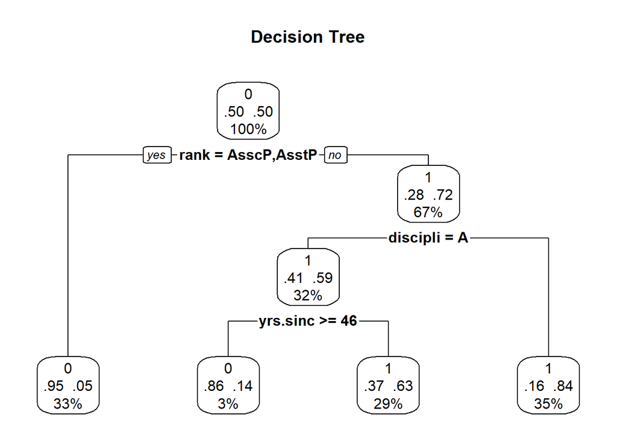

```r
dtree.pruned<-prune(dtree,cp=0.01630435)
library(rpart.plot)
prp(dtree.pruned,type = 2,extra = 104,
    fallen.leaves = TRUE,main="Decision Tree")
```

```r
dtree.pred<-predict(dtree.pruned,ndf.validate,type="class")
dtree.perf<-table(ndf.validate$bisalary,dtree.pred,
                  dnn = c("Actual","Predicted"))
dtree.perf
```

```
##       Predicted
## Actual  0  1
##      0 40 19
##      1  2 59
```

## Random forest

```r
library(randomForest)
ndf.train$bisalary<-as.factor(ndf.train$bisalary)
ndf.validate$bisalary<-as.factor(ndf.validate$bisalary)
fit.forest<-randomForest(bisalary~.,data = ndf.train,
                         importance=TRUE)
fit.forest
```

```
##
## Call:
##  randomForest(formula = bisalary ~ ., data = ndf.train, importance = TRUE)
##                Type of random forest: classification
##                      Number of trees: 500
## No. of variables tried at each split: 2
##
##         OOB estimate of  error rate: 21.66%
## Confusion matrix:
##    0   1 class.error
## 0 90  49  0.35251799
## 1 11 127  0.07971014
```

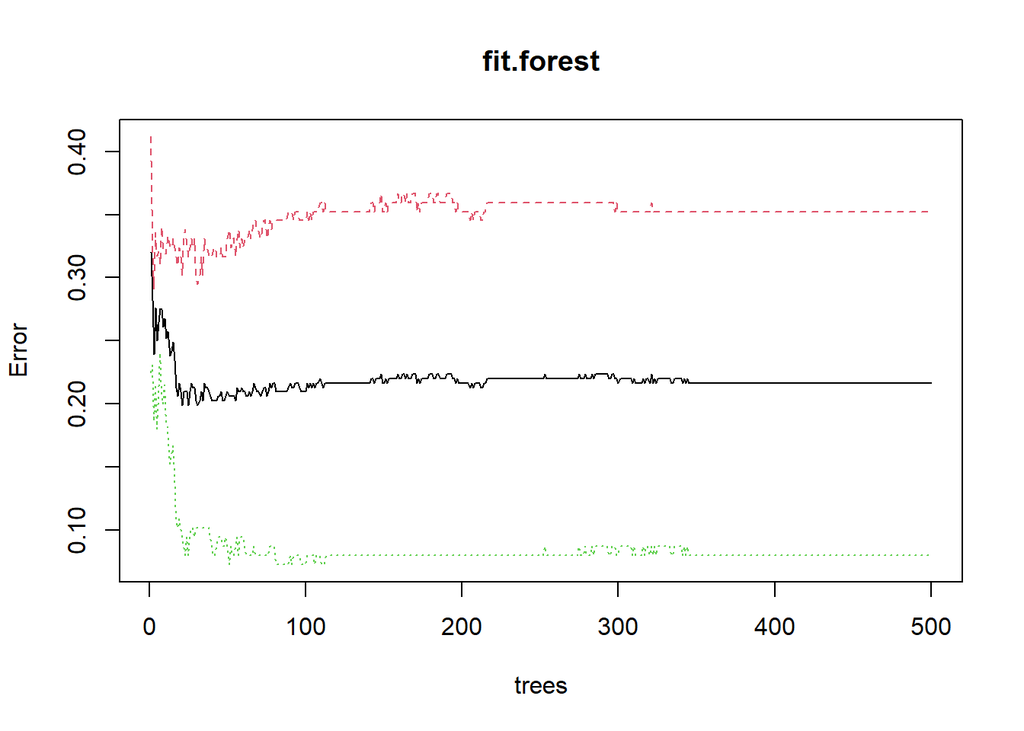

```r
plot(fit.forest)
```

On the plot, when ntree is larger than 200, the error rate tends to be constant, so we use ntree=200.

```r
n <- length(names(ndf.train))#find the best mtry
rate=1
for (i in 1:(n-1)) {
  set.seed(1234)
  rf_train <- randomForest(bisalary~.,data = ndf.train,mtry=i,ntree=200)
  rate[i] <- mean(rf_train$err.rate)
  print(rf_train)
  }
```

```
##
## Call:
##  randomForest(formula = bisalary ~ ., data = ndf.train, mtry = i,      ntree = 200)
##                Type of random forest: classification
##                      Number of trees: 200
## No. of variables tried at each split: 1
##
##         OOB estimate of  error rate: 20.58%
## Confusion matrix:
##    0   1 class.error
## 0 89  50  0.35971223
## 1  7 131  0.05072464
##
## Call:
##  randomForest(formula = bisalary ~ ., data = ndf.train, mtry = i,      ntree = 200)
##                Type of random forest: classification
##                      Number of trees: 200
## No. of variables tried at each split: 2
##
##         OOB estimate of  error rate: 22.02%
## Confusion matrix:
##    0   1 class.error
## 0 91  48   0.3453237
## 1 13 125   0.0942029
##
## Call:
##  randomForest(formula = bisalary ~ ., data = ndf.train, mtry = i,      ntree = 200)
##                Type of random forest: classification
##                      Number of trees: 200
## No. of variables tried at each split: 3
##
##         OOB estimate of  error rate: 22.74%
## Confusion matrix:
##    0   1 class.error
## 0 99  40   0.2877698
## 1 23 115   0.1666667
##
## Call:
##  randomForest(formula = bisalary ~ ., data = ndf.train, mtry = i,      ntree = 200)
##                Type of random forest: classification
##                      Number of trees: 200
## No. of variables tried at each split: 4
##
##         OOB estimate of  error rate: 26.35%
## Confusion matrix:
##     0   1 class.error
## 0 101  38   0.2733813
## 1  35 103   0.2536232
##
## Call:
##  randomForest(formula = bisalary ~ ., data = ndf.train, mtry = i,      ntree = 200)
##                Type of random forest: classification
##                      Number of trees: 200
## No. of variables tried at each split: 5
##
##         OOB estimate of  error rate: 25.27%
## Confusion matrix:
##     0   1 class.error
## 0 102  37   0.2661871
## 1  33 105   0.2391304
```

```r
fit.forest2<-randomForest(bisalary~.,data = ndf.train,mtry=3, ntree=200,
                         importance=TRUE)
fit.forest2
```

```
##
## Call:
##  randomForest(formula = bisalary ~ ., data = ndf.train, mtry = 3,      ntree = 200, importance = TRUE)
##                Type of random forest: classification
##                      Number of trees: 200
## No. of variables tried at each split: 3
##
##         OOB estimate of  error rate: 24.19%
## Confusion matrix:
##    0   1 class.error
## 0 99  40   0.2877698
## 1 27 111   0.1956522
```

```r
importance(fit.forest2,type = 2)
```

```
##               MeanDecreaseGini
## rank                 38.941114
## discipline            6.828859
## yrs.since.phd        41.956598
## yrs.service          34.448530
## sex                   1.204418
```

```r
forest.pred2<-predict(fit.forest2,ndf.validate)
forest.perf2<-table(ndf.validate$bisalary,forest.pred2,
                   dnn = c("Actual","Predicted"))
forest.perf2
```

```
##       Predicted
## Actual  0  1
##      0 42 17
##      1  9 52
```

## Support vector model (SVM)

```r
library(e1071)
fit.svm<-svm(bisalary~.,data=ndf.train)
fit.svm
```

```
##
## Call:
## svm(formula = bisalary ~ ., data = ndf.train)
##
##
## Parameters:
##    SVM-Type:  C-classification
##  SVM-Kernel:  radial
##        cost:  1
##
## Number of Support Vectors:  139
```

```r
svm.pred<-predict(fit.svm,ndf.validate)
svm.perf<-table(ndf.validate$bisalary,svm.pred,
                dnn = c("Actual","Predicted"))
svm.perf
```

```
##       Predicted
## Actual  0  1
##      0 37 22
##      1  2 59
```

## SVM with radial basis function (RBF)

```r
set.seed(1234)
tuned<-tune.svm(bisalary~.,data = ndf.train,
                2^(-1:1), cost = 2^(2:4))
tuned
```

```
##
## Parameter tuning of 'svm':
##
## - sampling method: 10-fold cross validation
##
## - best parameters:
##  cost
##    16
##
## - best performance: 0.2132275
```

```r
summary(tuned)
```

```
##
## Parameter tuning of 'svm':
##
## - sampling method: 10-fold cross validation
##
## - best parameters:
##  cost
##    16
##
## - best performance: 0.2132275
##
## - Detailed performance results:
##   cost     error dispersion
## 1    4 0.2133598 0.05648921
## 2    8 0.2133598 0.06357178
## 3   16 0.2132275 0.06731983
```

```r
fit.svm2<-svm(bisalary~.,data=ndf.train,cost=16)
svm.pred2<-predict(fit.svm2,ndf.validate)
svm.perf2<-table(ndf.validate$bisalary,svm.pred2,
                 dnn = c("Actual","Predicted"))
svm.perf2
```

```
##       Predicted
## Actual  0  1
##      0 39 20
##      1  2 59
```

## Performance of each model

```r
performance<-function(table,n=4){
  if(!all(dim(table)==c(2,2)))
    stop("Must be a 2 x 2 table")
  tn=table[1,1]
  fp=table[1,2]
  fn=table[2,1]
  tp=table[2,2]
  sensitivity=tp/(tp+fn)
  specificity=tn/(tn+fp)
  ppp=tp/(tp+fp)
  npp=tn/(tn+fn)
  hitrate=(tp+tn)/(tp+tn+fp+fn)
  result<-paste("Sensitivity=",round(sensitivity,n),
                "\nSpecificity=",round(specificity,n),
                "\nPositive Predictive Value=",round(ppp,n),
                "\nNegative Predicted Value=",round(npp,n),
                "\nAccuracy=",round(hitrate,n),"\n",sep = "")
  cat(result)
}
```

```r
performance(logit.perf)
```

```
## Sensitivity=0.8852
## Specificity=0.6441
## Positive Predictive Value=0.72
## Negative Predicted Value=0.8444
## Accuracy=0.7667
```

```r
performance(logit.perf.reduced)
```

```
## Sensitivity=0.9672
## Specificity=0.6271
## Positive Predictive Value=0.7284
## Negative Predicted Value=0.9487
## Accuracy=0.8
```

```r
performance(dtree.perf)
```

```
## Sensitivity=0.9672
## Specificity=0.678
## Positive Predictive Value=0.7564
## Negative Predicted Value=0.9524
## Accuracy=0.825
```

```r
performance(forest.perf2)
```

```
## Sensitivity=0.8525
## Specificity=0.7119
## Positive Predictive Value=0.7536
## Negative Predicted Value=0.8235
## Accuracy=0.7833
```

```r
performance(svm.perf)
```

```
## Sensitivity=0.9672
## Specificity=0.6271
## Positive Predictive Value=0.7284
## Negative Predicted Value=0.9487
## Accuracy=0.8
```

```r
performance(svm.perf2)
```

```
## Sensitivity=0.9672
## Specificity=0.661
## Positive Predictive Value=0.7468
## Negative Predicted Value=0.9512
## Accuracy=0.8167
```

# Data Set Enhancement

## Question (1)

**Problem 1:**

It is weird that years of service/years since PhD was first received is not significant to the linear regression model. However, in the random forest model, yrs.since.phd is the most important variable, and in the classification decision tree model, it is also used to do the classification.

I first thought it is because there is a multicollinearity between yrs.since.phd and yrs.service, but the regression result of keeping one of them is still insignificant.I tried generalized linear model, and the results are excellent: all variables are very significant, but the residuals are not independent of each other.Then I realized that salaries go up at first and down afterward by yrs.since.phd and by yrs.service, hence glm works while lm doesn’t.But it still goes against our common sense that salary is positively correlated with working experience.

To resolve it, I think enlarging sample size is necessary, and we can also compare the salaries by yrs.since.phd and by yrs.service in other universities. If they have the same trend of going up and down, then I think generalized linearity model could be good for analysis. If they are different, then we can use larger sample to do another linear regression, and compare two results.

**Problem 2:**

When I do the second analysis problem, I use Wilcoxon test to see whether there is statistically significant difference between female and male salaries, and the result shows that the statement is true. However, in the predictive models below, sex is the least important variables and make very less contribution to prediction.

The reason I think is that the number of female in this data set is much less than the number of male, which is 39 to 358, so that its impact might be ignored when doing prediction. So the sample size of female salaries must be enlarged to closed to the sample size of male salaries.

**Problem 3:**

The accuracy of prediction models is too low, which is only around 80%. As I tried using more than 5 different models and all of them don’t work very well, so I think the enhancement of data set will contribute more to accuracy than the improvement of models.

Again, enlarging sample size is the first thing. We can use power analysis to find the appropriate sample size.For example, we want to analyze the relationship between sex and salary, and we can see from the correlation matrix that the correlation between sex and salary is -0.1386102. Also, we want a significant level of 95% and a probability of 90% to test it:

```r
library(pwr)
pwr.r.test(r=-0.1386102,sig.level=0.05,power=0.9,alternative="two.side")
```

```
##
##      approximate correlation power calculation (arctangh transformation)
##
##               n = 541.9727
##               r = 0.1386102
##       sig.level = 0.05
##           power = 0.9
##     alternative = two.sided
```

So we need a sample size of 542 people to find out the relationship between sex and salary.

## Question (2)

Below are 6 variables I would like to add to the data set for more accurate salary analysis. These variables are based on my interview to a dean of the medical college in China university, since I didn’t find too much information about the component and effective factors of teachers’ salaries in America.

1. Administrative status: Teachers with administrative status, such as dean of college, department director, discipline leader, will earn higher salaries. Each administrative status is a 0/1 binary indicator, for instance, the indicator has a value of 1 if the teacher is dean of college and 0 otherwise. Since it is common that a department director is also the discipline leader, I won’t set this variable to be a categorical variable.
2. Impact Factor: Teachers who publish papers with high impact factor will earn more salaries. The increasing is non-linear, and the higher IF, the faster salaries growth. It is a categorical variable: IF≤5 ranked 1, 5<IF≤10 ranked 2, 10<IF≤15 ranked 3, 15<IF≤20 ranked 5, 20<IF≤25 ranked 6, and IF≥25 ranked 7.
3. Position: It is a categorical variable: senior teacher ranked 1, associated senior teacher ranked 2, secondary teacher ranked 3, otherwise ranked 4. In China, the average annual income of senior teachers is 143,600, that of associate senior teachers is 103,300, that of secondary teachers is 83,000, and that of junior teachers is 74,400.
4. University of graduation: Teachers graduating from top schools in the world will have higher basic salaries than those who are not. It is a categorical variable: Top 10 schools ranked 1, top 30 ranked 2, top 50 ranked 3, and 4 otherwise.
5. Class hour: It is a numerical variable. Teaching more class hours will bring higher income.
6. Honor: The income level of teachers with honors is 2.8 times of the average income of ordinary teachers in China. It is a categorical variable: Academician ranked 1, Chang Jiang Scholars ranked 2, Distinguished Young Scholars ranked 3, otherwise ranked 4.

## Question (3)

Take linear regression model as example, we can also use power analysis to estimate sample size. After adding 6 variables, we have 12 variables in total, 1 explained variable and 11 explanatory variables. If we want our new regression model only has a deviation of 1000, but in our previous research, the deviation could reach 21530, so the effective size is 0.046, which means new sample size will overlap the previous one by only 4.6%.

```r
pwr.f2.test(u=11,f2=0.046,sig.level=0.05,power=0.90)
```

```
##
##      Multiple regression power calculation
##
##               u = 11
##               v = 458.7536
##              f2 = 0.046
##       sig.level = 0.05
##           power = 0.9
```

So we need a sample size of 459+11+1=471 people.